# Propriedade Intelectual e Inovação

Gestão da Inovação Tecnológica  
Fundamentos e Práticas

Luiz Diego Vidal Santos

# Introdução

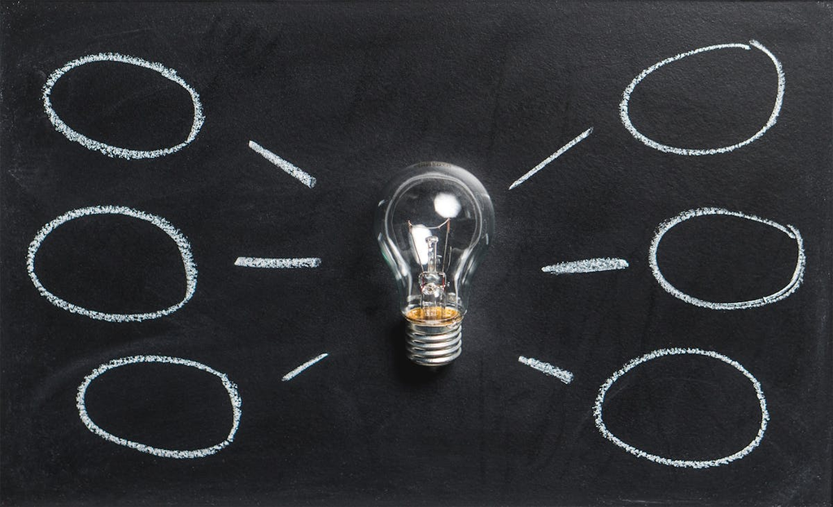

## A Inovação como Imperativo Estratégico

### Definição de Schumpeter (1942)

**Destruição Criativa**: Introdução de: - Novos bens - Novos métodos de produção - Abertura de novos mercados - Novas fontes de matéria-prima - Reorganização industrial

“Motor da destruição criativa”

### Evolução Teórica

**Fundamentos** - Schumpeter: Destruição criativa - Freeman (1987): Sistemas nacionais - Lundvall (1992): Sistemas de inovação

**Paradigmas Contemporâneos** - Inovação Aberta (Chesbrough, 2003) - Capacidades Dinâmicas (Teece, 2007) - Ecossistemas (Adner, 2006)

## Campo Multidisciplinar da Gestão da Inovação

### CaracterÃsticas Fundamentais

**Natureza Multidisciplinar** - Teorias organizacionais - Economia da inovação - Gestão estratégica

**Cenário Contemporâneo** - Intensa volatilidade - Rápida transformação digital - Conhecimento como vantagem competitiva

**Requisitos Gerenciais** - Mecanismos robustos - Processos sistemáticos - Governança estruturada

**Sistemas Integrados**

Diretrizes para formalizar: - Governança - Atividades inovativas - Mensuração de resultados - Otimização de ROI

**Objetivo**: Transformar esforços em processos sustentáveis

# ISO 56002: Contexto e LideranÃ§a

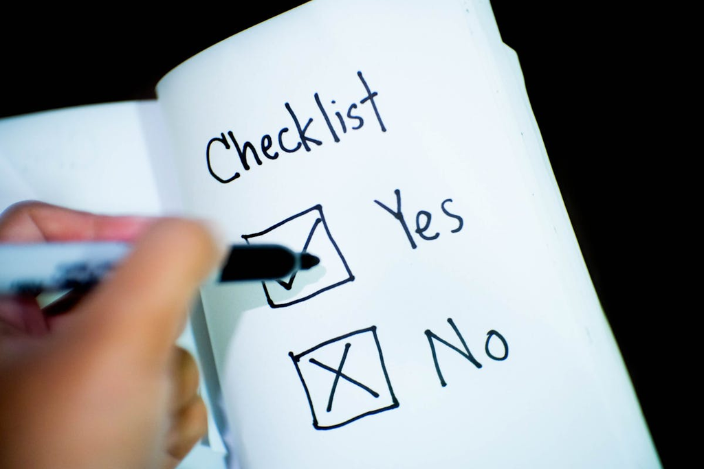

## Governança e Alinhamento Estratégico

### Cláusula 4: Contexto da Organização

**AnÃ¡lise do Ambiente** - Partes interessadas - Contexto interno e externo - Escopo do SGI

### Cláusula 5: Liderança

**Princípio 2**: Líderes focados no futuro - Inspirar e engajar equipes - Equilibrar curto e longo prazo - Investimento no futuro

### Cláusula 6: Direção Estratégica

**Alinhamento Estratégico** - Visão de inovação - Objetivos estratégicos - Política de inovação

## Inovação Aberta (Chesbrough, 2003)

### Conceito Central

“Construir modelo de negócio superior é mais importante que chegar primeiro ao mercado”

**Paradigma da Inovação Aberta** - Transcende P&D interna - Valoriza conhecimento externo - Explora PI estrategicamente - Colaboração interorganizacional

**Impacto na Direção Estratégica** - Redefine limites da organização - Amplia fontes de conhecimento - Diversifica rotas de mercado

### PrÃ©-requisitos

**Capacidade Absortiva** (Cohen & Levinthal, 1990)

Habilidade de: - Reconhecer valor da informação externa - Assimilar conhecimento - Aplicar comercialmente

**Características** - *Path-dependent* (cumulativa) - Construída ao longo do tempo - Essencial para spillovers

## Capacidade Absortiva: Função Dual da P&D

### Função Tradicional

**Geração de Inovações** - Pesquisa básica e aplicada - Desenvolvimento experimental - Prototipagem - Novos produtos/processos

### Função Estratégica

**Construção de Conhecimento** - Estoque de conhecimento prévio - Base para absorção externa - Integração de spillovers - Exploração de insights (Princípio 5 ISO)

**Implicação Estratégica**: Investimento em P&D não apenas como gerador direto de inovação, mas como capacitador da absorção e integração de conhecimento externo

# Processo de Inovação

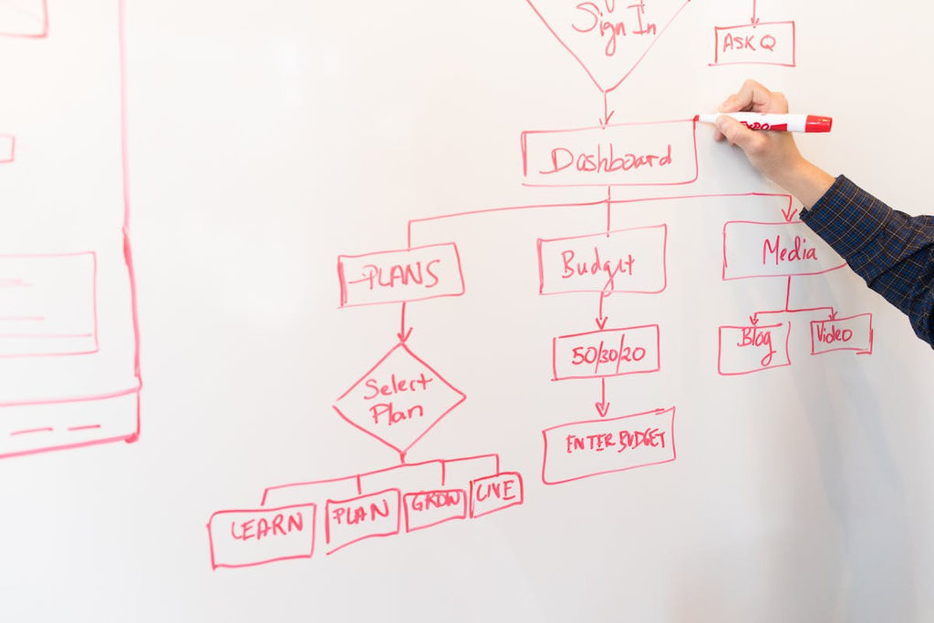

## Estruturação do Processo (ISO 56002)

### Cláusula 8: Operação

**Processo de Inovação** - Geração de ideias - Avaliação e seleção - Desenvolvimento - Comercialização - Proteção de PI

**Princípios Associados** - Princípio 4: Cultura - Princípio 8: Abordagem de Sistemas

### ClÃ¡usula 7: Apoio

**Recursos Necessários** - Pessoas e competências - Infraestrutura - Conhecimento organizacional - Comunicação

Base para implementação efetiva do processo de inovação

## Arquétipos da Inovação Aberta

### Gassmann & Enkel (2004): TrÃªs Processos Fundamentais

**Outside-In**

Integração de conhecimento externo - Parcerias - Aquisição de tecnologia - Colaboração com universidades - *Open sourcing*

**Inside-Out**

Comercialização de PI - *Spin-offs* - Licenciamento - Venda de patentes - Transferência tecnológica

**Coupled Process**

Co-criação interorganizacional - Joint ventures - Alianças estratégicas - Consórcios de P&D - Ecossistemas

**Alinhamento**: Gestão sistemática do fluxo de conhecimento e PI (Cláusula 8 ISO 56002)

## Tríplice Hélice e NITs

### Modelo Tríplice Hélice (Etzkowitz & Leydesdorff, 2000)

**HÃ©lice III: Interativa**

Inovação como resultado de interdependências:

Interdependências sistêmicas e co-evolução

**Características** - Superposição de funções - Hibridização institucional - Redes trilaterais

### Marco Legal Brasileiro

**Lei nº 10.973/2004** (alterada pela Lei nº 13.243/2016)

**Núcleos de Inovação Tecnológica (NITs)**

Funções como *Boundary Spanners*: - Interface universidade-empresa - Tradução de resultados científicos - Gestão de ativos estratégicos - Mediação de assimetrias

**Processo Inside-Out** na prÃ¡tica

## Sistematicidade nos Ambientes AcadÃªmicos

### Papel dos NITs (Aldrich & Herker, 1977)

**Boundary Spanners** - Conectam ambientes distintos - Mediam assimetrias cognitivas - Traduzem linguagens - Gerenciam expectativas temporais

**Desafios de Mediação** - Assimetria cognitiva: lógica científica vs. comercial - Assimetria temporal: horizontes de pesquisa vs. mercado - Valoração de tecnologias em estágios iniciais - Proteção intelectual vs. publicação

**Materialização da Política**

Os NITs executam: - Gestão de PI - Transferência de tecnologia - Negociação de contratos - Criação de spin-offs - Cultura de inovação

**Resultado**: Tradução de resultados científicos em ativos estratégicos

# Avaliação e Melhoria

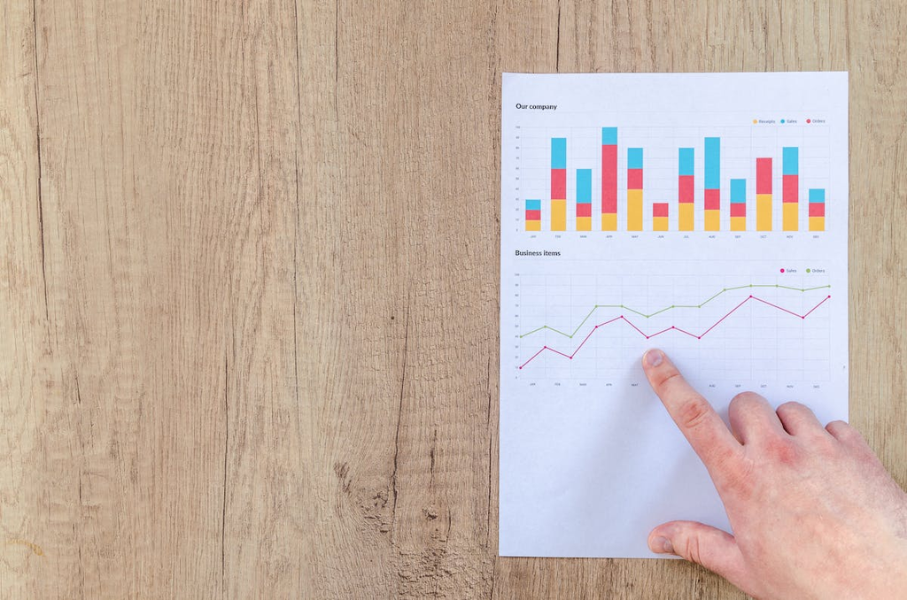

## Mensuração e Gestão da Incerteza

### Cláusula 9: Avaliação de Desempenho

**Princípio 6**: Gerenciamento da Incerteza - Monitoramento contínuo - Análise crítica - Avaliação de riscos - Aprendizado sistemático

**Princípio 1**: Realização de Valor - Criação de valor para stakeholders - Equilíbrio de interesses - Sustentabilidade

### ClÃ¡usula 10: Melhoria

**Não-conformidades** - Ações corretivas - Análise de causas-raiz

**Melhoria Contínua** - Aprendizado organizacional - Adaptação estratégica - Evolução do SGI

Ciclo PDCA aplicado Ã inovação

## Manual de Oslo: Métricas Sistêmicas

### OCDE/Eurostat (3ª Edição)

**Atividades de Inovação** (além de P&D):

- P&D interna e externa
- Aquisição de conhecimento externo
- Aquisição de máquinas e equipamentos
- Treinamento
- Introdução de inovações no mercado
- Design e outras preparações

Visão sistêmica alinhada Ã ISO 56002

### Mensuração Abrangente

**Tipos de Indicadores**

**Input** - Gastos em P&D - Investimento em PI - Capital humano

**Output** - Patentes - Publicações - Licenciamentos

**Processo** - Tempo de desenvolvimento - Taxa de sucesso

## Ecossistemas de Inovação

### Framework de Adner & Kapoor (2010)

**Componentes Upstream**

**Características** - Integrados - Intensivos em coordenação - Tecnologias centrais - Alto acoplamento

**Dinâmica** - Desafios reforçam incumbentes - Barreiras Ã entrada elevadas - Controle da cadeia de valor

**Complementos Downstream**

**Características** - Modulares - Desagregáveis - Aplicativos e serviços - Baixo acoplamento

**Dinâmica** - Desafios abrem espaço para entrantes - Barreiras Ã entrada reduzidas - Inovação descentralizada

**Implicação Estratégica**: Monitorar e coordenar dependências tecnológicas no ecossistema, antecipando gargalos upstream e explorando oportunidades downstream

## Complexidade da Realização de Valor

### Interdependências Tecnológicas

**Gestão Eficaz Requer** - Inovação interna - Monitoramento do ecossistema - Coordenação de dependências - Antecipação de gargalos - Exploração de oportunidades

Não basta inovar: é preciso orquestrar o ecossistema

### Estratégias por Posição

**Upstream (Componentes)** - Investimento em capacidades - Controle de interfaces - Padrões tecnológicos

**Downstream (Complementos)** - Abertura e modularidade - Plataformas - Ecossistema de parceiros

Estrutura de interdependências determina estratégias

## Caso UFS: Agitte.se

### Política Institucional de Inovação

**Dimensões Estratégicas** - Gestão de Propriedade Intelectual - Valoração de ativos intangíveis - Negociação de parcerias - Transferência de tecnologia - Empreendedorismo acadêmico

Operacionalização: **Agitte.se**

### Indicadores Multidimensionais

**Alinhados ao Manual de Oslo e ISO 56002**

**Input** - Gastos em PI - Investimento em NITs

**Output** - DepÃ³sitos de patentes - Contratos de licenciamento - Spin-offs criadas

**Processo** - Tempo médio de licensing - Taxa de transferência

## Exemplo de patente universitÃ¡ria

### Geocomposto Vegetal

- **DepÃ³sito de patente** junto ao INPI
- **Base científica** validada por publicações
- **Potencial de licenciamento** para indÃºstria de bioengenharia

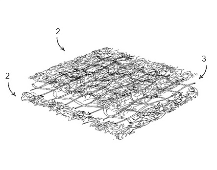

Patente de geocomposto vegetal - exemplo de output de PI universitÃ¡ria

# ConclusÃ£o

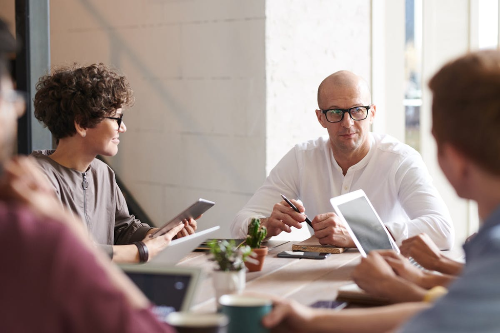

## SGI como Estrutura para Vantagem Competitiva

### Essência da Gestão da Inovação

**Abordagem Sistemática** - Transformação de conhecimento em valor - ISO 56002 como framework normativo - Integração de princípios

**Componentes Integrados** - Liderança - Cultura - Estratégia - Processo

### Alinhamento Teórico-Prático

**Conceitos Acadêmicos** - Capacidade Absortiva - Inovação Aberta - Ecossistemas de Inovação

**Estrutura ISO 56002** - Esforços repetíveis - Resultados mensuráveis - Sustentabilidade

Sistematicidade = Vantagem Competitiva

## Desafios Estruturais no Contexto Brasileiro

### Principais ObstÃ¡culos

**Assimetrias Informacionais** - Valoração de tecnologias em estágios iniciais - *Technology Readiness Levels* 2-4 - Dificuldade de precificação

**Cultura Institucional** - Proteção intelectual incipiente - Tensão publicação vs. patenteamento - Desconhecimento de mecanismos de transferência

**Divergências Temporais** - Pesquisa acadêmica: longo prazo - Expectativas empresariais: curto prazo - Assimetria de horizontes

**Consolidação do SGI**

**Requer** - Superação de barreiras culturais - Capacitação institucional - Alinhamento de incentivos - Investimento em estrutura

**Contexto**: Transição para economia do conhecimento

## Perspectivas Futuras

### Capacidades Ambidestras

**Equilíbrio entre** - **Exploração**: Pesquisa científica, novos domínios - **Explotação**: Aplicação de conhecimentos existentes

Organizações precisam gerenciar simultaneamente ambas as dimensões

### MÃ©tricas Balanceadas

**Harmonização** - Excelência científica - Impacto socioeconômico - Sustentabilidade

### Inovação para o Desenvolvimento

**Economia do Conhecimento** - Inovação como vetor de desenvolvimento - Responsabilidade social - Sustentabilidade ambiental - Inclusão tecnológica

**Objetivo Final**: SGI como instrumento de desenvolvimento sustentÃ¡vel e competitividade na economia do conhecimento

## ReferÃªncias

**ABNT NBR ISO 56002:2020**. *Sistema de gestão da inovação - Diretrizes*. Associação Brasileira de Normas Técnicas, 2020.

**ADNER, R.; KAPOOR, R.** Value creation in innovation ecosystems: how the structure of technological interdependence affects firm performance in new technology generations. *Strategic Management Journal*, v. 31, n. 3, p. 306-333, 2010.

**ALDRICH, H.; HERKER, D.** Boundary spanning roles and organization structure. *Academy of Management Review*, v. 2, n. 2, p. 217-230, 1977.

**CHESBROUGH, H.** *Open Innovation: The New Imperative for Creating and Profiting from Technology*. Harvard Business School Press, 2003.

**COHEN, W. M.; LEVINTHAL, D. A.** Absorptive Capacity: A New Perspective on Learning and Innovation. *Administrative Science Quarterly*, v. 35, n. 1, p. 128-152, 1990.

**ETZKOWITZ, H.; LEYDESDORFF, L.** The dynamics of innovation: from National Systems and “Mode 2” to a Triple Helix of university-industry-government relations. *Research Policy*, v. 29, n. 2, p. 109-123, 2000.

**GASSMANN, O.; ENKEL, E.** Towards a Theory of Open Innovation: Three Core Process Archetypes. *R&D Management Conference*, 2004.

**OCDE/Eurostat**. *Manual de Oslo: Diretrizes para Coleta e Interpretação de Dados sobre Inovação*, 3ª edição. FINEP, 2005.

**ROTHWELL, R.** Towards the fifth-generation innovation process. *International Marketing Review*, v. 11, n. 1, p. 7-31, 1994.

**SCHUMPETER, J. A.** *Capitalism, Socialism and Democracy*. Harper & Brothers, 1942.

**TEECE, D. J.** Explicating dynamic capabilities: the nature and microfoundations of enterprise performance. *Strategic Management Journal*, v. 28, n. 13, p. 1319-1350, 2007.

**WILLIAMSON, O. E.** *The Economic Institutions of Capitalism*. Free Press, 1985.

**Obrigado!**

**Luiz Diego Vidal Santos**

Universidade Federal de Sergipe